# rOceans

An R Package for exploring spatial trends in marine biodiversity and conservation. Here have examples of functions to access and explore spatial patterns of marine biodiversity. The functions are separated in set #1 for single or few species analyses and set #2 for analyzing large data sets downloaded from OBIS or GBIF.

*Currently, working on further set of functions to access and explore spatial data on climate change and other stressors as well as MPAs coverage.

1. Download rOceansNew from GitHub and load the package

```r
invisible(devtools::install_github("monteroserra/rOceansNew"))
```

```
## from URL https://api.github.com/repos/monteroserra/rOceansNew/zipball/master
```

```
## Installing rOceansNew
```

[output not shown]

```r
invisible(library(rOceansNew))
```

[output not shown]

[output not shown]

# Functions for accessing, merging and cleaning geographich occurrences data

## Function #1 *oceanDivDat*

Allows accessing occurrence data from GBIF and OBIS for a given vector of species names. It also allows merging data from these two sources and removing duplicates as well as land-based occurrences.

```r
# Define target species names: example with three corals
coral_species = c("Corallium rubrum", "Acropora palmata", "Paramuricea clavata")

# Get, merge and filter occurrences from GBIF & OBIS using oceanDivDat()
corals = oceanDivDat(species_names = coral_species,
                     data_source = "OBIS_&_GBIF",
                     remove_duplicates = T,
                     remove_land_dots = T)
```

```
##
Retrieved 19 records of 19 (100%)
##
Retrieved 2000 records of 6527 (30%)
Retrieved 4000 records of 6527 (61%)
Retrieved 6000 records of 6527 (91%)
Retrieved 6527 records of 6527 (100%)
##
Retrieved 32 records of 32 (100%)
```

Compute abundance per grid cell and visualize the results using *oceanAbunGrid()* & *oceanMaps()*

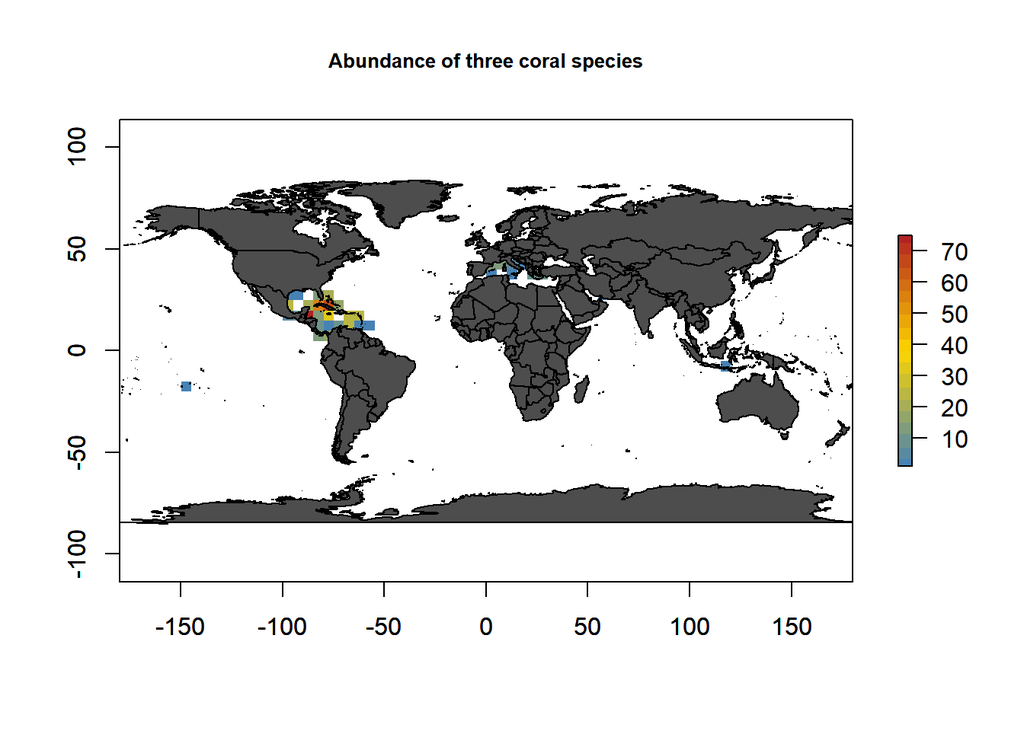

```r
#Compute abundance per grid cell

corals_abundance = oceanAbundGrid(corals)

oceanMaps(grid = corals_abundance, main = "Abundance of three coral species")
```

## Function #2 *oceanDataCheck*

Allows merging, checking, filtering the raw data from OBIS and/or GBIF into a common standard database. It removes occurrences with inconsistent or inconmplete taxonomic information, land-based occurrences, and duplicate occurrences.

For this set of functions, we first need to access and download data from GBIF (www.gbif.org) and OBIS (www.iobis.org).

Here I show an example with data of species within the genus *Acropora* that were directly downloaded from the website on June 2018. The data can be accessed from my GitHub repository “monteroserra/rOceanData” or using data()

```r
#Accesing raw datasets
data(Acropora_GBIF)
data(Acropora_OBIS)

#Checking OBIS or GBIF individually
Acropora_OBIS_checked = oceanDataCheck(OBIS_occurrences = Acropora_OBIS, source = "OBIS")
```

```
## 48142 duplicate data points were deleted
## 0 data points containing NAs were deleted
## 3980 land data points were deleted
```

```r
Acropora_GBIF_checked = oceanDataCheck(GBIF_occurrences = Acropora_GBIF, source = "GBIF")
```

```
## 26447 duplicate data points were deleted
## 1252 data points containing NAs were deleted
## 2135 land data points were deleted
```

Merging OBIS and GBIF Datasets, and checking for taxonomic and geographic issues

```r
Acropora_Total_Checked = oceanDataCheck(GBIF_occurrences = Acropora_GBIF,
                                        OBIS_occurrences = Acropora_OBIS,
                                        source = "GBIF_&_OBIS")
```

```
## 6278 occurrences were deleted from GBIF data due to a lack of standard species level information
## 88056 occurrences were deleted from OBIS data due to of standard species level information
## 21282 duplicate data points were deleted
## 1214 data points containing NAs were deleted
## 1914 land data points were deleted
```

# Functions for analyzing and visualizing spatial trends in marine biodiversity

## Function #3 *oceanAbundGrid*

Allows creating global or delimited spatial grids with abundance of occurrences per cell at differenc cell sizes.

Following with the Acropora example, we will use this function to compute global rasters of abundance per grid cell for Acropora species at different resolutions (10 x 10?) (5 x 5?) (1? x 1?) and (0.5 x 0.0?) using *cell_size*

```r
Acropora_abundance_10x10 = oceanAbundGrid(occurrences = Acropora_Total_Checked, cell_size=10)
Acropora_abundance_5x5 = oceanAbundGrid(occurrences = Acropora_Total_Checked, cell_size=5)
Acropora_abundance_1x1 = oceanAbundGrid(occurrences = Acropora_Total_Checked, cell_size=1)
Acropora_abundance_0.5x0.5 = oceanAbundGrid(occurrences = Acropora_Total_Checked, cell_size=0.5)
```

## Function #3 *oceanMaps*

A versatile data mapping tool for a rapid visualization of marine biodiversity patterns previously computed.

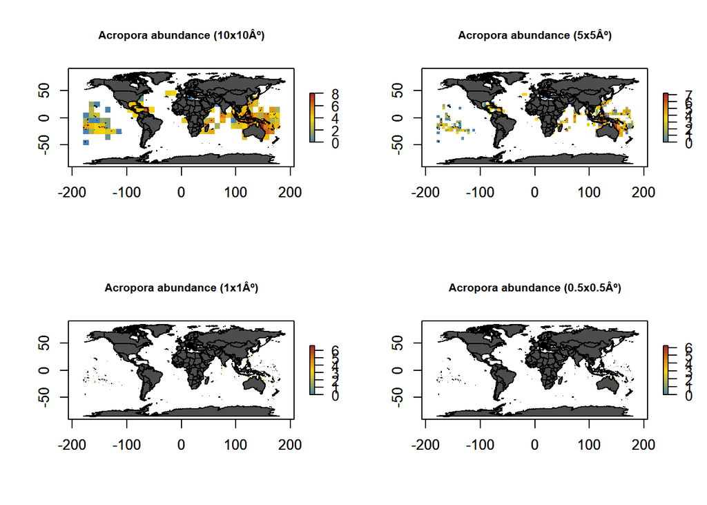

```r
par(mfrow=c(2,2))
oceanMaps(Acropora_abundance_10x10, logScale=T, main="Acropora abundance (10x10Âº)")
oceanMaps(Acropora_abundance_5x5, logScale=T, main="Acropora abundance (5x5Âº)")
oceanMaps(Acropora_abundance_1x1, logScale=T, main="Acropora abundance (1x1Âº)")
oceanMaps(Acropora_abundance_0.5x0.5, logScale=T, main="Acropora abundance (0.5x0.5Âº)")
```

```r
par(mfrow=c(1,1))
```